Alessandro Morita, Sep 2020

# Introduction

**MCMC (Markov Chain Monte Carlo)** is a family of methods for estimating a target **probability distribution** without explicitly calculating its analytical form.

Let $f$ be the desired distribution (which is unknown) and let $g$ be a function such that $$f(x) = \frac 1 Z g(x)$$

for some constant $Z > 0$, ie. $g$ is an unnormalized version of $f$ (this is the standard case in Bayesian statistics as we will see below).

It turns out we can use $g$ to actually sample directly from $f$, by **constructing a Markov chain whose equilibrium distribution equals $f$**. We can then use the elements of this Markov chain as our samples, obtaining $f$ via their histogram / empirical distribution.

Below, we will see:

- A review of the notion of Markov chains: definition, asymptotic behavior
- The Metropolis-Hastings class of algorithms for creating a Markov chain replicating our target distribution
- Hamiltonian Monte-Carlo and NUTS, special cases of the Metropolis-Hastings algorithm which are widely used in practice

# Motivation

Let $f: \mathbb{R} \to \mathbb{R}_+$ be a PDF of some 1D random variable $X$, i.e. integrable and satisfying $$\int_{\mathbb{R}} f(x) dx = 1$$.

We know that the **expected value** of $X$ is then computed as $$\mathbb{E}[X] := \int_{\mathbb{R}} x f(x) dx,$$ which in many cases might be hard to do analytically. However, **it can be also be approximated via sampling**: let $X_1,\ldots, X_n$ be iid copies of $X$. Then the *sample mean* $$\hat x_n := \frac 1n \sum_{i=1}^n X_i$$ is an unbiased, efficient estimator for $\mathbb{E}[X]$, in the sense that $$\mathbb{E}[\hat x_n] = \mathbb{E}[X]\quad\forall n\in \mathbb B, \qquad \lim_{n\to\infty} \mathrm{Var}[\hat x_n] = 0$$

Thus, we learn an important lesson: *we can use samplings to approximate complex integrals*.

This also means we can obtain an estimate for $f$ simply by simulating the process $X$ and checking its histogram. **This is called Monte-Carlo simulation**.

## Example of Monte-Carlo simulation: approximating stock returns

```python
import numpy as np
import matplotlib.pyplot as plt
from tqdm.notebook import tqdm
```

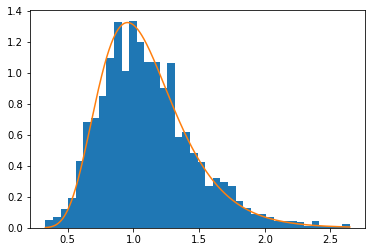

```python
def mc_stock_returns(S0=1, mu=0.1, sigma=0.1, T=10, N=1000):

    # N sequences of length T variables
    samples = np.random.randn(N,T)*sigma + 1 + mu
    samples = np.product(samples, axis=1)

    return samples

# run simulation
S0=1; mu=0.01; sigma=0.1; T=10; N=2000
samples = mc_stock_returns(S0, mu, sigma, T, N)

# plot
plt.hist(samples, bins=40, density=True)

# plot theoretical curve: obtained from dS/S = mu dt + sigma dW SDE
x = np.linspace(min(samples), max(samples), 1000)
import scipy.stats
plt.plot(x, [scipy.stats.lognorm.pdf(xx, s=sigma*np.sqrt(T), loc=T*(mu-sigma**2/2)) for xx in x])
plt.show()
```

Curiosity: in the limit of small $R_i$, one can take $\log S_T = \log S_0 + \sum_i \log(1+R_i) \approx \log S_0 + \sum_i R_i$, which is normal! The distribution of $S_T$ in this approximation is perfectly lognormal.

# Markov chains

## Definition

A Markov chain is a probabilistic dynamical system.

Its states are a set $S$, which for simplicity we will take to be finite. Then, the *full* dynamics of the system is given by the **transation matrix**

$$\boxed{P_{ij}(t) := P(S_{t} = j | S_{t-1} = i)}$$

In the vast majority of applications we assume a **stationary** system: $P_{ij}(t) = P_{ij}$.

It is important to notice that a Markov chain is **memoryless**: all information prior to time $t$ is irrelevant in order to determine where the system will move to at $t+1$. In other words,

$$\boxed{P(S_t = i | S_{t-1}, S_{t-2},\ldots,S_t) = P(S_t = i | S_{t-1}) \mbox{ only}}$$

**Comment**: Markov chains are the base structure of all reinforcement learning, so we will use it in future iterations as well!

## Evolution

Now, suppose we have an initial distribution $\pi_i(t) = P(S_t = i)$ at time $t$ over states.

**Problem 1**: prove that the distribution at time $t+1$ will be $$\pi_j(t+1) = \sum_i \pi_i (t) P_{ij}$$.

Thinking of $\pi$ as a vector of size $|S|$, this actually says that the evolution map is $$\pi_t \mapsto \pi_t P$$

## Convergence

One question one is then tempted to ask is: what is the behavior of this mapping as $t\to\infty$? In other words, how does $\lim_{n\to\infty} P^n$ behave?

If there *is* such a limit $P^\infty$, it must be true that $$\pi_* = \pi_* P$$ for some vector $\pi_*$. This means that **the asymptotic distribution, if exists, is the eigenvector of $P$ corresponding to the eigenvalue 1**.

### Example 1

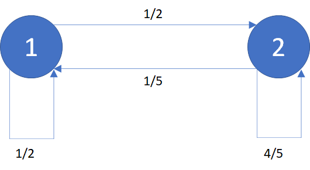

The system above has a transition matrix $$P = \begin{pmatrix} 1/2 & 1/2 \\ 1/5 & 4/5 \end{pmatrix}$$

The solution of the eigenequation $\pi_* = \pi_* P$ (or, in more usual form, $P^T \pi_*^T = \pi_*^T$) is $$\pi_* = (2/7, 5/7)$$

Let's see if we can find this distribution from the limit $\lim_{n\to\infty} P^n$ as well.

One can calculate the power $P^n$ by diagonalizing $P = U D U^{-1}$; we can then show that $$U = \begin{pmatrix} 1 & 5 \\ 1 & -2 \end{pmatrix}$$ and that $D = \mathrm{diag}(1, 3/10)$. We can then prove that $\lim_{n\to\infty} P^n = U \mathrm{diag}(1, 0) U^{-1} = \begin{pmatrix} 2/7 & 5/7 \\ 2/7 & 5/7 \end{pmatrix}$.

Notice how the equilibrium distribution appears as the degenerate rows of this matrix!

```python
# Calculate P and its infinite power
P = np.array([[1/2, 1/2], [1/5, 4/5]])
P_inf = np.linalg.matrix_power(P, 10000)
print(P_inf)
```

```
[[0.28571429 0.71428571]
 [0.28571429 0.71428571]]
```

```python
# Calculate eigendecomposition for P
# notice that we are interested in left eigenvectors, since pi = pi P is our eigenequation.
# This amounts to normal eigendecomposition for transpose(P_inf)
eigenvalues, eigenvectors = np.linalg.eig(P.T)  # careful! Eigenvectors here are normalized in L2 norm
                                                    # but we need probabilities, i.e. the element-wise squares
eigenvectors = (eigenvectors**2).T             # transposing to get the columns
print(f"Eigenvalues: {eigenvalues}")
print(f"Eigenvector corresponding to \lambda=1: {eigenvectors[eigenvalues.tolist().index(1.)]}")
```

```
Eigenvalues: [0.3 1. ]
Eigenvector corresponding to \lambda=1: [0.13793103 0.86206897]
```

### Example 2

It is not always the case that Markov chains will have a limit distribution. Consider the system below with an *absorbing state*:

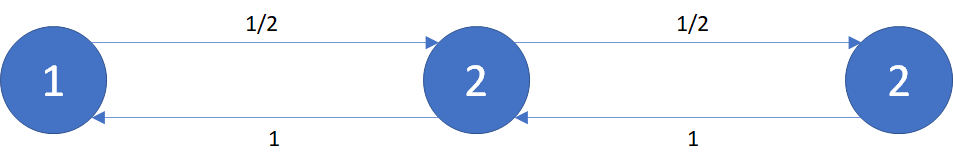

Then $$P = \begin{pmatrix} 0 & 1 & 0\\ 1/2 & 0 & 1/2\\ 0 & 1 & 0 \end{pmatrix}$$

## A good enough result for us

There are several technical results detailing when and how an asymptotic limit for $P$ exists. For us, it will be enough to go with the following result:

**Detailed balance**

> A Markov process is called a **reversible Markov chain** if it satisfies the **detailed balance equations**: $$\boxed{\pi _{i}P_{ij}=\pi _{j}P_{ji}, \qquad \forall i, j}$$ where $\pi$ is the equlibrium distribution.

One can show that such Markov chains are ergodic (thus, technically speaking, acyclic and positive recurrent) and the equilibrium distribution is unique.

This is a **core result** for us: we can revert engineer the whole thing, and actually choose a $\pi$ that we are interested in while choosing a sufficiently simple $P$. This will be the key behind the Metropolis-Hastings algorithm.

# Bayesian statistics

In the Bayesian setting, we are interested in obtaining the best possible parameters $\theta \in \mathbb{R}^d$ that describe the law of a random variable $X$, given data $\mathbf{X} = (X_1,\ldots, X_n)$. We suppose that $\theta$ has a *prior* distribution $p(\theta)$, and we wish to obtain an updated estimate given the data, $p(\theta|\mathbf{X})$.

Bayes rule then gives: $$\boxed{p(\theta|\mathbf{X}) = \frac{p(\mathbf X|\theta) p(\theta)}{\int_{\mathbb{R}^d} p(\mathbf X|\theta') p(\theta') d\theta'} \propto p(\mathbf X|\theta) p(\theta)}$$

Notice that in the Bayesian setting, the numerator of the RHS is something we have. However, the denominator is usually very hard to calculate. This is where Monte-Carlo methods, and Markov chains, become important.

# MCMC and the Metropolis-Hastings algorithm

The Metropolis-Hastings algorithm is a structured way of creating a Markov chain whose equilibrium distribution is a desired target distribution $f$ if we are only given a multiple $g = Zf$ of it. This is useful exactly because, in the Bayesian setting, we have control over the $p(\mathbf X|\theta) p(\theta)$ term but not the partition function $\int_{\mathbb{R}^d} p(\mathbf X|\theta') p(\theta') d\theta'$.

Let's give the algorithm right away and then discuss why it works.

**Metropolis-Hastings algorithm**

Inputs: $\pi(x)$ (up to a constant), a **transition kernel** $P(x|y)$, a large integer $N$;

Initialize: $x_1$

For $t$ in 1:N:

```
* y = sample from P(.,x_t)
* Compute acceptance probability:
```

$$\alpha = \min\left(1, \frac{\pi(y)}{\pi(x_t)} \frac{P(x_t|y)}{P(y|x_t)}\right)$$

```
* Set
```

$$ x_{t+1} = y \mbox{ with probability }\alpha, \mbox{ or}$$$$ x_{t+1} = x_t \mbox{ with probability }1-\alpha \mbox{ ("rejection")}$$

## Comments on the Metropolis-Hastings algorithm

- The transition kernel $P(x|y)$ above is nothing but the probability matrix for a Markov chain; in fact, by defining $P$, we are implicitly defining a Markov chain
- Effectively, sampling $y \sim P(\cdot | x_t)$ is a way of walking around the phase space, or moving around the Markov chain. It should be intuitive that a good choice of $P$ can make convergence better and faster, and our discussion below (on Hamiltonian Monte-Carlo) will come back to this point.
- Notice that the acceptance probability contains a term that, if detailed balance is satisfied, is identically equal to 1 and thus there is no rejection
- **Burn-in**: since our Markov chain only converges asymptotically to the stable distribution, it usually happens that the first values are very far from the desired distribution, and must be ignored. We call this the burn-in period of the chain. Determining it is a hard task and highly dependent on the task.
- **Correlations**: in the paradigm we talked about in the introduction, we discussed how **iid** samples can be used to approximate the desired random variable. In the MCMC case, it is no longer true that the samples are independent - after all, they are related by the transition probabilities of the the Markov chain in question. It is also a research topic on how uncorrelated samples are between themselves, and how much that slows convergence.

## Why does Metropolis-Hastings work?

Source: https://gregorygundersen.com/blog/2019/11/02/metropolis-hastings/

## Example: the beta-binomial conjugate pair

Consider a coin which might or not be biased, with parameter $p \in ]0,1[$. Suppose we observe a sequence of $N =10$ data points $(1,1,1,0,0,1,0,1,1,0)$.

We want to find the best estimate for $p$. Let $X$ be the number of 1's obtained in the sequence of throws above.

- $X$ is distributed as a binomial variable with parameters $N$ and $p$: $$P(X=k) = \binom{N}{k} p^k (1-p)^{N-k}$$
- $p$ will be distributed with a (uninformative) prior, $p \sim \mathrm{Unif}([0,1])$, with PDF $$P(p) = \mathbb{I}_{p \in [0,1]}$$

Now, we can actually plug these values into Bayes' formula, calculate the partition function analytically, and show that the posterior $p|X$ follows a $\mathrm{Beta}(7,5)$ law.

> This is a particular case of the **beta-binomial** model. In a model where the prior is a $p \sim \mathrm{Beta}(\alpha,\beta)$ distribution and the likelihood is a $X \sim \mathrm{Binom}(n,p)$, then, if $k$ heads and $n-k$ tails were observed, the posterior will also follow an updated Beta distribution:

> $$p|X \sim \mathrm{Beta}(\alpha+k,\beta+n-k)$$

> .

In particular, the uniform distribution that we used is a $\mathrm{Beta}(1,1)$, and so we are within the Beta-Binomial case.

The "probability" (the quotes are here because this does not integrate to 1) we will be using is then $$\tilde \pi(p) = P(X|p)p(p) = \binom{10}{6}p^6(1-p)^4 \times \mathbb{I}_{p\in[0,1]}$$ $$\Rightarrow\tilde\pi(p) = 210p^6(1-p)^4\mathbb{I}_{p\in[0,1]}$$

Notice that we can analytically integrate this (giving 1/11), so we immediately get that the correct posterior is $$\pi(p) = 2310 p^6(1-p)^4\mathbb{I}_{p\in[0,1]}$$.

Let us use a Gaussian transition kernel for our Metropolis-Hastings model: $$P(x|y) = \frac{1}{\sqrt{2\pi}} e^{-(x-y)^2/2} \sim N(y, \sigma^2=1).$$

*Notice that this kernel is symmetric*; this actually simplifies the acceptance probability calculation, with the fraction $P(x|y)/P(y|x)$ cancelling out. This is an example of a **Metropolis** algorithm.

```python
def pi(p):
    if (p > 1) or (p < 0):
        return 0
    else:
        return p**6*(1-p)**4  # any constant factors here do not matter

def real_posterior(p):
    return 2310*p**6*(1-p)**4
```

```python
def metropolis_gaussian_kernel(pi, N=10000):
    """
    N: size of the chain
    pi: one-argument function proportional to target distribution

    Returns: x (Markov chain in format of list)
    """
    x = [np.random.rand()]  # random initial value (adapted to this problem)
    for _ in tqdm(range(N)):
        y = np.random.normal(loc=x[-1])
        alpha = min(1, pi(y)/pi(x[-1]))
        if np.random.rand() < alpha:  # with probability alpha, set x_{t+1} = y
            x.append(y)
        else:
            x.append(x[-1])
    return x
```

```python
x = metropolis_gaussian_kernel(pi=pi, N=30000)

# remove burn-in
x = x[2000:]
```

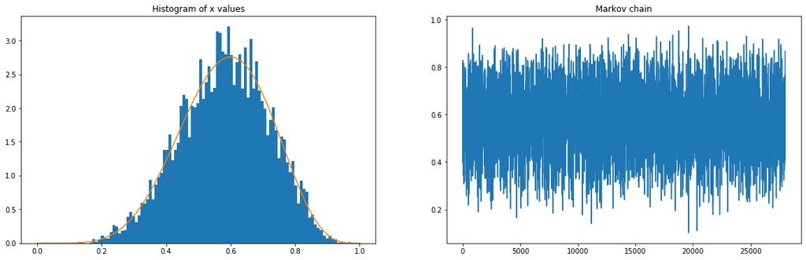

```python
fig, (ax1, ax2) = plt.subplots(ncols=2, figsize=(20,6))
ax1.hist(x, density=True, bins=100)

x_axis = np.linspace(0,1)
ax1.plot(x_axis, [real_posterior(xx) for xx in x_axis])
ax2.plot(x, label='True posterior')
ax1.set_title("Histogram of x values")
ax2.set_title("Markov chain")
plt.show()
```

# Hamiltonian Monte-Carlo

Reference: https://arxiv.org/pdf/1206.1901.pdf

The last topic for us to discuss is a class of Metropolis-Hastings algorithms called **Hamiltonian Monte-Carlo** methods.

The basic idea is to define an effective energy $E(x)$ for each state $x$ in our system, and sample via the Gibbs distribution in the canonical ensemble: $$p(x) = \frac{1}{Z(\beta)} e^{-\beta E(x)}$$ Notice that, if we are interested in a target distribution $p$, we can **always find a suitable energy functional** in the Gibbs form above which gives $p$, namely: $$E(x) = -\frac{1}{\beta} \log(Z(\beta)p(x))$$ (the proof is trivial). How does it help to put the problem in this form?

Let $q$ be the vector denoting our parameters (in our prior; one example is $p$ in the example above), and define its conjugate momentum as $p$. One can build a Hamiltonian $$H(p,q) = K(p) + U(q).$$

If we fix a pair $(q_0, p_0)$ of initial conditions and let the system evolve under Hamilton's equations, then it will follow a constant-energy hypersurface in the phase space. If we let it run for time $T$, reaching a state $(q_T, p_T)$, then we can in fact say that the transition is $(q_0, p_0) \mapsto (q_T,p_T)$; since Hamiltonian mechanics are time-reversible, this defines a reversible Markov Chain.

## Leapfrog algorithm

Hamiltonian mechanics are usually discretized via the leapfrog algorithm, which ensures the volume preservation properties of Hamiltonian flow.

Compare how these work for a 1st order Euler method vs. the leapfrog:

**Euler** $$ \begin{align} p(t+\epsilon) &= p(t) + \epsilon \frac{dp}{dt}(t) = p(t) - \epsilon \frac{\partial U}{\partial q}(q(t))\\ q(t+\epsilon) &= q(t) + \epsilon \frac{dq}{dt}(t) = q(t) + \epsilon \frac{p(t)}{m} \end{align} $$

**Leapfrog** $$ \begin{align} p(t+\epsilon/2) &= p(t) - \frac{\epsilon}{2} \frac{\partial U}{\partial q}(q(t))\\ q(t+\epsilon) &= q(t) + \epsilon \frac{p(t+\epsilon/2)}{m}\\ p(t+\epsilon) &= p(t+\epsilon/2) - \frac{\epsilon}{2} \frac{\partial U}{\partial q}(q(t+\epsilon))\\ \end{align} $$

The amount of steps ($T$) that we take, and the step size ($\epsilon$), are parameters of our HMC model.

## The essence of HMC

First, we set the temperature to 1 ($\beta = 1$). The kinetic energy can be written as (in the simplest case of equal masses) $$K(p) = \frac{|p|^2}{2m}$$ where the masses can be customized to each problem.

Momentum will be sampled from a normal distribution at each step.

The greatest change is in the acceptance probability. **HMC is a Metropolis-Hastings algorithm**; as such, only the acceptance probabilities are changed:

$$\alpha = \min\left(1, \exp(-H(q_T, p_T) + H(q_0, p_0))\right)$$

```python
def leapfrog(p, q, U_grad, eps=0.1, mass=1):
    p_prime = p - (eps/2)*U_grad(q)
    qq = q + eps*p_prime/mass
    pp = p_prime - (eps/2)*U_grad(qq)
    return pp, qq
```

```python
def HMC(pi, grad_pi, N=10000, eps=0.01, T=1000):
    """
    N: size of the chain
    eps: step-size for the leapfrog algorithm
    T: total time steps for leapfrog algorithm
    pi: one-argument function proportional to target distribution
    grad_pi: derivative of pi

    Returns: x (Markov chain in format of list)
    """

    # define kinetic and potential energy
    # all temperatures will be set to 1
    def U(q):
        return -np.log(pi(q))

    def U_grad(q):
        if pi(q) == 0:
            return 0
        else:
            return -grad_pi(q)/(pi(q))

    def K(p):
        return p**2/2

    def H(q,p):
        return U(q) + K(p)

    q_list = [np.random.rand()]

    for _ in tqdm(range(N)):

        p = np.random.randn()
        q = q_list[-1]

        H0 = H(q, p)

        # run leapfrog evolution
        for __ in range(T):
            p, q = leapfrog(p, q, U_grad, eps, mass=1)

        H1 = H(q, p)

        alpha = min(1, np.exp(-H1 + H0))
        if np.random.rand() < alpha:
            q_list.append(q)
        else:
            q_list.append(q_list[-1])

    return q_list
```

### Example: the coin toss with Hamiltonian MC

In our previous example, ignoring constants, $$\pi(p) = p^6(1-p)^4\mathbb{I}_{p\in[0,1]}.$$ This means that its derivative is $$\pi'(p) = 2p^5(1-p)^3(3-5p)\mathbb{I}_{p\in[0,1]}$$

```python
def pi(p):
    if (p > 1) or (p < 0):
        return 0
    else:
        return p**6*(1-p)**4  # any constant factors here do not matter

def grad_pi(p):
    if (p > 1) or (p < 0):
        return 0
    else:
        return 2*p**5*(1-p)**3*(3-5*p)
```

```python
q = HMC(pi, grad_pi, N=10000, eps=0.05, T=30)
```

```python
# Remove burn-in
q = q[1000:]
```

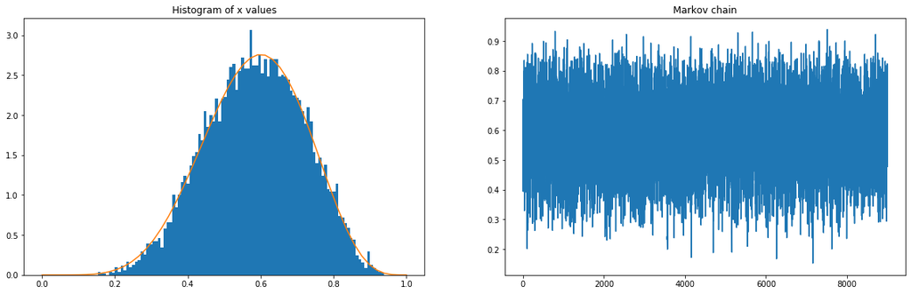

```python
fig, (ax1, ax2) = plt.subplots(ncols=2, figsize=(20,6))
ax1.hist(q, density=True, bins=100)

x_axis = np.linspace(0,1)
ax1.plot(x_axis, [real_posterior(xx) for xx in x_axis])
ax2.plot(q, label='True posterior')
ax1.set_title("Histogram of x values")
ax2.set_title("Markov chain")
plt.show()
```

Notice that we get an even better curve than for random Walk Metropolis-Hastings, and using 1/3 of the samples.

### NUTS (No U-Turn Sampler)

The algorithm actually used by PyMC3, Stan and other probabilistic programming languages is the No U-Turn sampler, or NUTS ( Hoffman and Gelman (2011)). It does two things for us:

- Does not need a number of time steps for Hamiltonian evolution - instead, finds one adaptatively
- Avoids the possibility of doing a U-turn and getting too close to the initial point. It does so by propagating from $q_0$ both with momentum $p_0$ and $-p_0$, i.e. creating two opposite going trajectories

Amazing visualizations: http://elevanth.org/blog/2017/11/28/build-a-better-markov-chain/